# Pamatstatistiskie testi programmā R

## Lekcijas tēmas

- Statistiskie rādītāji
- Paraugkopu salīdzināšana
- Korelācijas analīze
- Regresijas analīze
- Dispersijas analīze

## Statistiskie rādītāji

## Dati

```r
niedr<-read.table(file="../Dati/niedres2.txt",header=TRUE,sep="\t",dec=".")
```

```r
str(niedr)
```

```
'data.frame':   50 obs. of  3 variables:
 $ garums : num  31.6 23.2 39.2 37.4 21.1 37 24.7 31.3 37.4 39.7 ...
 $ platums: num  2.5 2.3 2.1 5.8 2.2 4.1 3.5 4.2 2.5 2.8 ...
 $ paraug : Factor w/ 3 levels "Austr","Riet",..: 1 1 1 1 1 1 1 1 1 1 ...
```

## Statistiskie rādītāji 1

Vidējo aritmētisko, standartnovirzi, dispersiju un mediānu aprēķina attiecīgi ar funkcijām `mean()`, `sd()`, `var()` un `median()`. Visām šīm funkcijām kā arguments jānorāda skaitļu vektors/viena kolonna.

```r
mean(niedr$garums)
```

```
[1] 37.594
```

```r
sd(niedr$garums)
```

```
[1] 10.31332
```

```r
var(niedr$garums)
```

```
[1] 106.3647
```

```r
median(niedr$garums)
```

```
[1] 38.4
```

## Statistiskie rādītāji 2

Skaitļu noapaļošanai izmanto funkciju `round()`, kurā norāda vienu skaitli, vai objektu ar vairākiem skaitļiem un decimāldaļu skaitu aiz komata.

```r
round(mean(niedr$garums),1)
```

```
[1] 37.6
```

## Statistiskie rādītāji 3

```r
x <- c(1:20,NA)
mean(x)
```

```
[1] NA
```

```r
mean(x,na.rm=TRUE)
```

```
[1] 10.5
```

Daudzas funkcijas R dod rezultātu NA, ja kāda no apstrādājamām vērtībām arī ir NA. Tāpēc jānorāda, ko darīt ar šīm NA vērtībām.

## Statistiskie rādītāji 4

Minimālo un maksimālo vērtību aprēķina ar funkcijām `min()` un `max()`, vai arī ar funkciju `range()` var aprēķināt abas vērtības uzreiz.

```r
min(niedr$garums)
```

```
[1] 11.9
```

```r
max(niedr$garums)
```

```
[1] 59
```

```r
range(niedr$garums)
```

```
[1] 11.9 59.0
```

## Statistiskie rādītāji 5

Kvartiles aprēķina ar funkciju `quantile()`. Ja nepieciešams aprēķināt procentiles, vai arī tikai kādu no kvartilēm, tad papildus norāda argumentu `probs=` un vajadzīgo rādītāju izteiktu decimāldaļās.

```r
quantile(niedr$garums)
```

```
    0%    25%    50%    75%   100%
11.900 31.075 38.400 45.300 59.000
```

```r
quantile(niedr$garums,probs=c(0.025,0.975))
```

```
  2.5%  97.5%
18.465 55.770
```

## Statistiskie rādītāji 6

Ja funkcijā `summary()` ievieto skaiļu vektoru, rezultātā iegūst sešus statistiskos rādītājus, kas to raksturo.

```r
summary(niedr$garums)
```

```
   Min. 1st Qu.  Median    Mean 3rd Qu.    Max.
  11.90   31.08   38.40   37.59   45.30   59.00
```

## Statistiskie rādītāji 7

Ja funkcijā `summary()` ievieto datu tabulu, rezultātā katrai skaitliskajai kolonnai iegūst sešus statistiskos rādītājus, bet faktoram/rakstu zīmju kolonnai iegūst vērtību atkārošanās biežumu.

```r
summary(niedr)
```

```
     garums         platums        paraug
 Min.   :11.90   Min.   :0.400   Austr:17
 1st Qu.:31.07   1st Qu.:2.500   Riet :17
 Median :38.40   Median :3.900   Ziem :16
 Mean   :37.59   Mean   :3.892
 3rd Qu.:45.30   3rd Qu.:5.100
 Max.   :59.00   Max.   :7.100
```

## Paraugkopu salīdzināšana

## Dati 1

```r
niedr2<-read.table(file="../Dati/lapas.txt", header=TRUE,sep="\t",dec=".")
```

```r
str(niedr2)
```

```
'data.frame':   34 obs. of  3 variables:
 $ garums : num  31.6 23.2 39.2 37.4 21.1 37 24.7 31.3 37.4 39.7 ...
 $ platums: num  2.5 2.3 2.1 5.8 2.2 4.1 3.5 4.2 2.5 2.8 ...
 $ paraug : Factor w/ 2 levels "Austr","Riet": 1 1 1 1 1 1 1 1 1 1 ...
```

## Dispersiju salīdzināšana 1

Dispersiju salīdzināšanu ar F testu veic izmantojot funkciju `var.test()`.

```r
var.test(pirmā.paraugkopa,otrā.paraugkopa)

var.test(datu.kolonna~grupu.kolonna)
```

## Dispersiju salīdzināšana 2

```r
var.test(niedr2$garums~niedr2$paraug)
```

```
    F test to compare two variances

data:  niedr2$garums by niedr2$paraug
F = 0.89492, num df = 16, denom df = 16, p-value = 0.827
alternative hypothesis: true ratio of variances is not equal to 1
95 percent confidence interval:
 0.3240865 2.4711930
sample estimates:
ratio of variances
         0.8949191
```

## Dispersiju salīdzināšana 3

**Secinājums:** Pie būtiskuma līmeņa \(\alpha=0,05\) divu paraugkopu dispersijas ir homogēnas (neatšķiras būtiski), jo iegūtā F-vērtība ir 0,89 un p-vērtība ir 0,827 (lielāka par 0,05). Ja skatās uz F vērtības ticamības intervālu, tad tas satur skaitli viens (0,32 līdz 2,47), tātad dispersijas ir līdzīgas (homogēnas).

## Vidējo aritmētisko salīdzināšana 1

Vidējo aritmētisko salīdzināšanai izmanto funkciju `t.test()`. Ja pirms tam pierādīts, ka dispersijas neatšķiras, tad jāpievieno arguments `var.equal=TRUE`.

```r
t.test(datu.kolonna~grupu.kolonna,var.equal=TRUE)

t.test(paraugkopa1,paraugkopa2,var.equal=TRUE)
```

## Vidējo aritmētisko salīdzināšana 2

```r
t.test(niedr2$garums~niedr2$paraug,var.equal=TRUE)
```

```
    Two Sample t-test

data:  niedr2$garums by niedr2$paraug
t = -2.4034, df = 32, p-value = 0.02221
alternative hypothesis: true difference in means is not equal to 0
95 percent confidence interval:
 -13.899897  -1.147161
sample estimates:
mean in group Austr  mean in group Riet
           33.52941            41.05294
```

## Vidējo aritmētisko salīdzināšana 3

**Secinājums:** Pie būtiskuma līmeņa \(\alpha=0,05\) pastāv statistiski būtiska atšķirība starp Austrumu un Rietumu parauglaukumu vidējiem niedru lapu garumiem (p-vērtība=0,022). Vidējo aritmētisko starpības 95% ticamības intervāls ir no -13,89 līdz -1,15. Intervāls nesatur 0 (ja satūrētu 0, tad tas norādītu, ka atšķirība nav būtiska).

## Saistītu paraugkopu vidējo aritmētisko salīdzināšana 1

Saistītu vai atkarīgu paraugkopu vidējo aritmētisko salīdzināšanu veic ar funkciju `t.test()`, kurai papildus iekļauj argumentu `paired=TRUE`. Šī testa veikšanai abu paraugkopu datiem parasti jāatrodas katrai savā kolonnā.

```r
t.test(x,y,paired=TRUE)
```

## Saistītu paraugkopu vidējo aritmētisko salīdzināšana 2

```r
rokas <- read.table(file="../Dati/rokas.txt",header=TRUE,sep="\t",dec=".")
```

```r
str(rokas)
```

```
'data.frame':   25 obs. of  2 variables:
 $ laba  : num  32.9 39.7 26.9 38.8 58 50.6 31.4 68.7 65.2 31.8 ...
 $ kreisa: num  21.9 39.2 29.9 34.8 48.7 51.4 34.5 56.4 57.5 27.8 ...
```

## Saistītu paraugkopu vidējo aritmētisko salīdzināšana 3

```r
t.test(rokas$laba,rokas$kreisa,paired=TRUE)
```

```
    Paired t-test

data:  rokas$laba and rokas$kreisa
t = 4.4743, df = 24, p-value = 0.0001581
alternative hypothesis: true difference in means is not equal to 0
95 percent confidence interval:
 2.413454 6.546546
sample estimates:
mean of the differences
                   4.48
```

## Saistītu paraugkopu vidējo aritmētisko salīdzināšana 4

**Secinājums:** Pie būtiskuma līmeņa \(\alpha = 0,05\) pastāv statistiski būtiska atšķirība starp labās un kreisās rokas spēku (p-vērtība <0,001). Vidējā pāru starpība ir 4,48 un tās 95% ticamības intervāls ir no 2,41 līdz 6,54.

## T-tests vienai paraugkopai 1

Lai pārbaudītu vienas paraugkopas vērtību atbilstību zināmai vērtībai (ģenerālkopas vidējam aritmētiskajam), izmanto funkciju `t.test()`, kurai kā papildus argumentu norāda zināmo vērtību `mu=`.

```r
t.test(analizējamā.paraugkopa,mu=zināmā.vērtība)
```

## T-tests vienai paraugkopai 2

```r
t.test(niedr2$platums,mu=3.0)
```

```
    One Sample t-test

data:  niedr2$platums
t = 2.5592, df = 33, p-value = 0.01526
alternative hypothesis: true mean is not equal to 3
95 percent confidence interval:
 3.139297 4.219526
sample estimates:
mean of x
 3.679412
```

## T-tests vienai paraugkopai 3

**Secinājums:** pie būtiskuma līmeņa \(\alpha = 0,05\) niedru lapu platums pētītajā teritorijā būtiski atšķiras no vērtības 3 mm (p vērtība ir 0,015). Niedru lapu platumu vidējais aritmētiskais ir 3,68 un tā 95% ticamības intervāls ir no 3,14 līdz 4,22 (nesatur vērtību 3,0).

## Neparametriskās metodes - neatkarīgas paraugkopas 1

Neatkarīgu paraugkopu salīdzināšanai ar neparametriskajām metodēm izmanto funkciju `wilcox.test()`.

```r
wilcox.test(datu.kolonna~grupu.kolonna)

wilcox.test(pirma.paraugkopa,otra.paraugkopa)
```

## Neparametriskās metodes - neatkarīgas paraugkopas 2

```r
wilcox.test(niedr2$garums~niedr2$paraug)
```

```
Warning in wilcox.test.default(x = c(31.6, 23.2, 39.2, 37.4, 21.1, 37,
24.7, : cannot compute exact p-value with ties
```

```
    Wilcoxon rank sum test with continuity correction

data:  niedr2$garums by niedr2$paraug
W = 75, p-value = 0.01745
alternative hypothesis: true location shift is not equal to 0
```

## Neparametriskās metodes - neatkarīgas paraugkopas 3

**Secinājums:** Pie būtiskuma līmeņa \(\alpha = 0,05\) starp Austrumu un Rietumu parauglaukumu niedru lapu garumu vērtību sadalījumiem pastāv statistiski būtiska atšķirība (p vērtība 0,017).

## Neparametriskās metodes - atkarīgas paraugkopas 1

Saistītu vai atkarīgu paraugkopu vērtību sadalījuma salīdzināšanu veic ar funkciju `wilcox.test()`, kurai papildus iekļauj argumentu `paired=TRUE`. Šī testa veikšanai abu paraugkopu datiem parasti jāatrodas katram savā kolonnā.

```r
wilcox.test(pirma.paraugkopa,otra.paraugkopa, paired=TRUE)
```

## Neparametriskās metodes - atkarīgas paraugkopas 2

```r
wilcox.test(rokas$laba,rokas$kreisa,paired=TRUE)
```

```
Warning in wilcox.test.default(rokas$laba, rokas$kreisa, paired = TRUE):
cannot compute exact p-value with ties
```

```
    Wilcoxon signed rank test with continuity correction

data:  rokas$laba and rokas$kreisa
V = 291.5, p-value = 0.0005445
alternative hypothesis: true location shift is not equal to 0
```

## Neparametriskās metodes - atkarīgas paraugkopas 3

**Secinājums:** Pie būtiskuma līmeņa \(\alpha = 0,05\) pastāv statistiski būtiska atšķirība starp labās un kreisās rokas spēka vērtību sadalījumu (p-vērtība 0,0005).

## \(\chi^2\) tests 1

\(\chi^2\) testa veikšanai izmanto funkciju `chisq.test()`, kurai kā argumentus norāda empīrisko vērtību sadalījumu un sagaidāmo vērtību sadalījumu (kā iespējamības vērtības), ja jāsalīdzina ar teorētisko sadalījumu, vai arī matrici, kas satur divu paraugkopu vērtību sadalījumus, ja jāsalīdzina divas paraugkopas.

```r
chisq.test(empir.sad.vektors,teor.sad.vektors)
chisq.test(vertibu.matrice)
```

## \(\chi^2\) tests 2

```r
zirni <- c(315, 108, 101, 32)
#dala ar vērtību summu (16), lai iegūtu iespējamības vērtības
teor.zirni <- c(9, 3, 3, 1)/16

chisq.test(x = zirni, p = teor.zirni)
```

```
    Chi-squared test for given probabilities

data:  zirni
X-squared = 0.47002, df = 3, p-value = 0.9254
```

## \(\chi^2\) tests 3

**Secinājums:** Pētījumā iegūto zirņu pazīmju skaldīšanās atbilst teorētiski sagaidāmajai pazīmju skaldīšanās attiecībai 9:3:3:1, jo iegūtā p vērtība (0,9254) ir lielāka par būtiskuma līmeni 0,05.

## \(\chi^2\) tests 4

```r
koki<-matrix(c(12,34,56,23,8,27,33,47,14,11),ncol=2)

rownames(koki) <- c("Priede","Egle","Bērzs","Ozols","Kļava")
colnames(koki) <- c("Paraug A","Paraug B")

koki
```

```
       Paraug A Paraug B
Priede       12       27
Egle         34       33
Bērzs        56       47
Ozols        23       14
Kļava         8       11
```

## \(\chi^2\) tests 5

```r
chisq.test(koki)
```

```
    Pearson's Chi-squared test

data:  koki
X-squared = 9.2298, df = 4, p-value = 0.05561
```

**Secinājums:** Pie būtiskuma līmeņa \(\alpha = 0,05\) nav statistiski būtiskas atšķirības starp koku sugu sadalījumu divos parauglaukumos (p-vērtība 0,056). Tomēr būtu jāņem vērā, ka p-vērtība ir tuvu kritiskajai robežai. Iespējams, ka palielinot datu apjomu, atšķirība jau būtu būtiska.

## Korelācijas analīze

## Funkcijas analīzes veikšanai

Pamatfunkcijas korelācijas analīzes veikšanai ir `cor()` un `cor.test()`.

Pirmajā funkcijā var likt gan atsevišķus vektorus (kolonnas), gan vienu vai divas vienāda garuma datu tabulas. Otrajā funkcijā var likt tikai divus vektorus (kolonnas), starp kurām jāaprēķina korelācijas koeficients.

Pēc noklusējuma abas funkcijas aprēķina Pīrsona korelācijas koeficientu. Ja nepieciešams cits, tad attiecīgi jāpievieno arguments `method="kendall"` vai `method="spearman"`.

Ja datos ir iztrūkstošās vērtības (NA), pievieno argumentu `use="pairwise.complete.obs"`.

## Dati

```r
smiltaji <- read.table(file="../Dati/smiltaji.txt",header=TRUE,sep="\t",dec=".")
```

```r
str(smiltaji)
```

```
'data.frame':   73 obs. of  4 variables:
 $ pH    : num  7.9 7.6 7 7.1 7.2 6.7 5.8 6.7 7.3 7.5 ...
 $ smilts: int  27 36 47 35 24 35 27 29 48 48 ...
 $ sunas : int  17 44 33 61 56 56 61 60 25 41 ...
 $ sugas : int  7 6 6 6 7 6 6 7 6 6 ...
```

## Grafiskā analīze

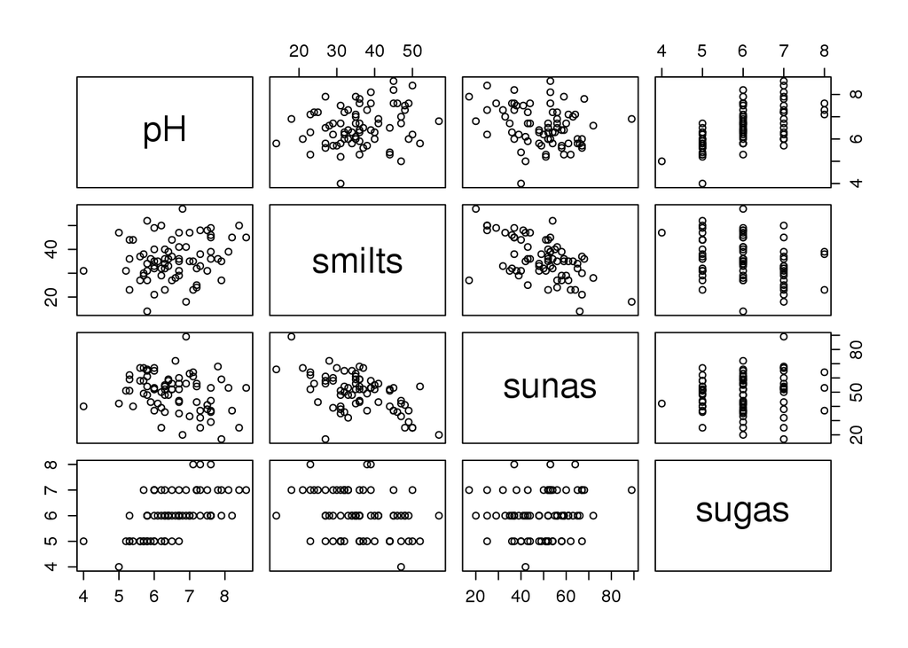

```r
pairs(smiltaji)
```

## Pīrsona korelācijas koeficients 1

```r
cor(smiltaji[,1:3])
```

```
               pH     smilts      sunas
pH      1.0000000  0.2213315 -0.2517885
smilts  0.2213315  1.0000000 -0.5576408
sunas  -0.2517885 -0.5576408  1.0000000
```

Funkcijas `cor()` rezultātos ir redzama korelācijas koeficientu matrica, bet neparādās korelācijas koeficientu būtiskumi (p vērtības).

## Pīrsona korelācijas koeficients 2

Funkcijai `rcor.test()` arī ir iespējams pievienot argumentu `method=`.

```r
if (!require("ltm") )  install.packages("ltm")
library(ltm)
rcor.test(smiltaji[,1:3])
```

```
       pH     smilts sunas
pH      *****  0.221 -0.252
smilts  0.060  ***** -0.558
sunas   0.032 <0.001  *****

upper diagonal part contains correlation coefficient estimates
lower diagonal part contains corresponding p-values
```

**Secinājums:** statistiski būtiska korelācija pie būtiskumu līmeņa \(\alpha=0,05\) pastāv starp pH un sūnu segumu un sūnu un smilts segumiem, jo atbilstošās p vērtības ir mazākas par būtiskuma līmeni.

## Pīrsona korelācijas koeficients 3

```r
cor.test(smiltaji$pH,smiltaji$sunas)
```

```
    Pearson's product-moment correlation

data:  smiltaji$pH and smiltaji$sunas
t = -2.1922, df = 71, p-value = 0.03164
alternative hypothesis: true correlation is not equal to 0
95 percent confidence interval:
 -0.45547107 -0.02305682
sample estimates:
       cor
-0.2517885
```

**Secinājums:** Pastāv statistiski būtiska negatīva korelācija starp pH un sūnu segumu (-0,25), jo p vērtība ir mazāka par būtiskuma līmeni (0,032<0,05).

## Spirmena korelācijas koeficients

```r
cor.test(smiltaji$sugas,smiltaji$smilts,method="spearman")
```

```
Warning in cor.test.default(smiltaji$sugas, smiltaji$smilts, method =
"spearman"): Cannot compute exact p-value with ties
```

```
    Spearman's rank correlation rho

data:  smiltaji$sugas and smiltaji$smilts
S = 83657, p-value = 0.01265
alternative hypothesis: true rho is not equal to 0
sample estimates:
       rho
-0.2905304
```

**Secinājums:** Pastāv statistiski būtiska negatīva korelācija starp sugu skaitu un smilts segumu (-0,29), jo p vērtība ir mazāka par būtiskuma līmeni (0,013<0,05).

## Kendela korelācijas koeficients

```r
cor.test(smiltaji$sugas,smiltaji$smilts,method="kendall")
```

```
    Kendall's rank correlation tau

data:  smiltaji$sugas and smiltaji$smilts
z = -2.5457, p-value = 0.0109
alternative hypothesis: true tau is not equal to 0
sample estimates:
       tau
-0.2335632
```

**Secinājums:** Pastāv statistiski būtiska negatīva korelācija starp sugu skaitu un smilts segumu (-0,23), jo p vērtība ir mazāka par būtiskuma līmeni (0,011<0,05).

## Regresijas analīze

## Regresijas analīzes funkcijas

Regresijas analīzes veikšanai izmanto funkciju `lm()`, kurai kā argumentus norāda pārbaudāmo formulu (regresents~regresors), kā arī datu tabulu, kurā atrodas mainīgie.

Regresijas analīzes rezultātu apskata ar funkciju `summary()`.

```r
modelis <- lm(regresents~regresors,data=datu.tabula)

summary(modelis)
```

## Dati

```r
bietes <- read.table(file = "../Dati/bietes.txt", header = TRUE)
```

```r
str(bietes)
```

```
'data.frame':   28 obs. of  2 variables:
 $ udens: int  0 0 0 0 48 50 48 50 88 88 ...
 $ svars: num  9 10.3 11.5 14.2 12.2 13.8 14 16.2 14 14.5 ...
```

```r
summary(bietes)
```

```
     udens           svars
 Min.   :  0.0   Min.   : 9.00
 1st Qu.: 50.0   1st Qu.:14.15
 Median :147.5   Median :16.85
 Mean   :131.8   Mean   :15.80
 3rd Qu.:209.2   3rd Qu.:17.65
 Max.   :239.0   Max.   :19.20
```

## Pāru regresijas analīze

```r
modelis <- lm(svars ~ udens, data = bietes)
summary(modelis)
```

```
Call:
lm(formula = svars ~ udens, data = bietes)

Residuals:
    Min      1Q  Median      3Q     Max
-3.2541 -0.8541 -0.0317  0.6903  2.6002

Coefficients:
             Estimate Std. Error t value Pr(>|t|)
(Intercept) 12.254121   0.506327  24.202  < 2e-16 ***
udens        0.026914   0.003269   8.232 1.03e-08 ***
---
Signif. codes:  0 '***' 0.001 '**' 0.01 '*' 0.05 '.' 0.1 ' ' 1

Residual standard error: 1.408 on 26 degrees of freedom
Multiple R-squared:  0.7227,    Adjusted R-squared:  0.7121
F-statistic: 67.77 on 1 and 26 DF,  p-value: 1.031e-08
```

## Pāru regresijas analīzes secinājumi

- Determinācijas koeficients Adjusted R-Squared = 0,712, tas ir, ūdens daudzums izskaidro 71,2% no svara vērtību variēšanas
- Gan viss lineārās regresijas modelis kopumā, gan arī atsevišķi šī modeļa koeficienti ir būtiski, jo atbilstošās p-vērtības ir mazākas par būtiskuma līmeni
- Lineārās regresijas vienādojums ir svars = 12,25+0,0269 x udens

## Modeļa diagnostika 1

Diagnosticējošos attēlos redzamas atlikuma vērtības pret prognozētajām vērtībām, atlikuma vērtību QQ attēls, kā arī attēls, kas parāda katra novērojuma ietekmi uz modeli (apakšējais labais attēls). Ja ietekmes attēlā kāds punkts atrodas aiz raustītās līnijas (Cook's distance virs 0,5), novērojums uzskatāms par ietekmīgu.

```r
par(mfrow = c(2, 2))
plot(modelis)
par(mfrow = c(1, 1))
```

## Modeļa diagnostika 2

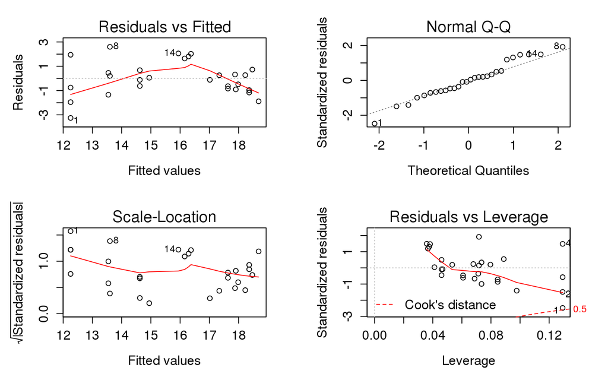

## Vērtību prognozēšana 1

Funkcija `coefficients()` no regresijas analīzes objekta paņem regresijas vienādojuma koeficientus.

```r
koef <- coefficients(modelis)
koef
```

```
(Intercept)       udens
12.25412112  0.02691369
```

```r
udens2 <- 301
raza2 <- koef[1] + koef[2] * udens2
raza2
```

```
(Intercept)
   20.35514
```

## Vērtību prognozēšana 2

Vērtību prognozēšanai var izmantot funkciju `predict()`, kurai kā argumentus norāda izveidoto modeli, kā arī datu tabulu ar jaunajām vērtībām. Šajā tabulā jābūt identiskiem kolonnu nosaukumiem kā modelī izmantotajiem regresoriem.

```r
jaunidati <- data.frame(udens = 301)
predict(modelis, jaunidati, interval = "confidence")
```

```
       fit      lwr      upr
1 20.35514 19.09301 21.61727
```

## Daudzfaktoru regresijas analīzes funkcijas

Regresijas analīzes veikšanai izmanto funkciju `lm()`, kurai kā argumentus norāda pārbaudāmo formulu (regresents~regresors1+regresors2+..), kā arī datu tabulu, kurā atrodas mainīgie.

Regresijas analīzes rezultātu apskata ar funkciju `summary()`.

```r
modelis <- lm(regresents~regresors1+regresors2+regresors3+
                ...+regresorsK,data=datu.tabula)

summary(modelis)
```

## Dati 1

```r
dati <- read.table(file = "../Dati/renda.txt", header = TRUE)
```

```r
str(dati)
```

```
'data.frame':   81 obs. of  6 variables:
 $ gads: int  1924 1925 1926 1927 1928 1929 1930 1931 1932 1933 ...
 $ hron: num  0.894 1.099 0.891 0.96 0.835 ...
 $ dec : num  -3.2 -5.8 -3.4 -3.1 -5.5 -3 1.7 -2.8 -1.5 1.7 ...
 $ jan : num  -8.2 1.5 -5 -5.2 -2.6 -7.1 0.5 -4.5 0.3 -6.5 ...
 $ feb : num  -7.1 1.3 -4.7 -3.7 -3.6 -14 -3.7 -6.2 -6.5 -4.3 ...
 $ mar : num  -3.3 -1.5 -0.6 1.7 -2.2 -2.3 0.4 -4.9 -5.2 0.1 ...
```

## Dati 2

```r
summary(dati)
```

```
      gads           hron             dec              jan
 Min.   :1924   Min.   :0.6280   Min.   :-8.800   Min.   :-12.900
 1st Qu.:1944   1st Qu.:0.9100   1st Qu.:-5.500   1st Qu.: -6.500
 Median :1964   Median :1.0090   Median :-3.100   Median : -3.600
 Mean   :1964   Mean   :0.9923   Mean   :-2.499   Mean   : -4.136
 3rd Qu.:1984   3rd Qu.:1.0860   3rd Qu.: 1.100   3rd Qu.: -1.300
 Max.   :2004   Max.   :1.1910   Max.   : 3.800   Max.   :  2.400
      feb               mar
 Min.   :-14.000   Min.   :-10.800
 1st Qu.: -6.600   1st Qu.: -3.100
 Median : -4.000   Median : -0.900
 Mean   : -4.257   Mean   : -1.259
 3rd Qu.: -1.000   3rd Qu.:  0.500
 Max.   :  3.700   Max.   :  3.700
```

## Modeļa definēšana

```r
modelis <- lm(hron ~ dec + jan + feb + mar, data = dati)

summary(modelis)
```

## Regresijas rezultāts

```
Call:
lm(formula = hron ~ dec + jan + feb + mar, data = dati)

Residuals:
      Min        1Q    Median        3Q       Max
-0.234333 -0.066903  0.007898  0.072541  0.187510

Coefficients:
             Estimate Std. Error t value Pr(>|t|)
(Intercept)  1.031433   0.018172  56.759  < 2e-16 ***
dec         -0.004039   0.003105  -1.301  0.19733
jan         -0.005548   0.003789  -1.464  0.14728
feb          0.012333   0.003700   3.333  0.00133 **
mar          0.015654   0.004704   3.328  0.00135 **
---
Signif. codes:  0 '***' 0.001 '**' 0.01 '*' 0.05 '.' 0.1 ' ' 1

Residual standard error: 0.09739 on 76 degrees of freedom
Multiple R-squared:  0.3508,    Adjusted R-squared:  0.3167
F-statistic: 10.27 on 4 and 76 DF,  p-value: 1.061e-06
```

## Regresijas analīze - secinājumi

- Regresijas modelis izskaidro 31,7% no vērtību variēšanas.
- Modelis kopumā ir būtisks (p vērtība <0,001), bet atsevišķu faktoru (decembra un janvāra temperatūras) ietekme nav būtiska (p vērtības attiecīgi 0,1973 un 0,1473).
- Tā kā atsevišķu regresoru ietekme nav būtiska, var veidot vienkāršāku modeli.

## Modeļa definēšana

```r
modelis1 <- lm(hron ~ jan + feb + mar, data = dati)

summary(modelis1)
```

## Regresijas rezultāts

```
Call:
lm(formula = hron ~ jan + feb + mar, data = dati)

Residuals:
      Min        1Q    Median        3Q       Max
-0.229956 -0.072878 -0.002383  0.078372  0.187456

Coefficients:
             Estimate Std. Error t value Pr(>|t|)
(Intercept)  1.036591   0.017814  58.191  < 2e-16 ***
jan         -0.006298   0.003762  -1.674  0.09818 .
feb          0.011864   0.003699   3.207  0.00195 **
mar          0.015783   0.004724   3.341  0.00129 **
---
Signif. codes:  0 '***' 0.001 '**' 0.01 '*' 0.05 '.' 0.1 ' ' 1

Residual standard error: 0.09783 on 77 degrees of freedom
Multiple R-squared:  0.3364,    Adjusted R-squared:  0.3105
F-statistic: 13.01 on 3 and 77 DF,  p-value: 5.849e-07
```

## Regresijas analīze - secinājumi

- Regresijas modelis izskaidro 31,1% no vērtību variēšanas.
- Modelis kopumā ir būtisks (p vērtība <0,001), bet janvāra temperatūru ietekme joprojām nav būtiska (p vērtība ir 0,0982).
- Tā kā atsevišķu regresoru ietekme nav būtiska, var veidot vienkāršāku modeli.

## Modeļa definēšana

```r
modelis2 <- lm(hron ~ feb + mar, data = dati)

summary(modelis2)
```

## Regresijas rezultāts

```
Call:
lm(formula = hron ~ feb + mar, data = dati)

Residuals:
     Min       1Q   Median       3Q      Max
-0.25327 -0.08051  0.00321  0.07134  0.17581

Coefficients:
            Estimate Std. Error t value Pr(>|t|)
(Intercept) 1.049088   0.016360  64.126  < 2e-16 ***
feb         0.008973   0.003309   2.712  0.00823 **
mar         0.014798   0.004741   3.121  0.00253 **
---
Signif. codes:  0 '***' 0.001 '**' 0.01 '*' 0.05 '.' 0.1 ' ' 1

Residual standard error: 0.09895 on 78 degrees of freedom
Multiple R-squared:  0.3122,    Adjusted R-squared:  0.2946
F-statistic: 17.71 on 2 and 78 DF,  p-value: 4.573e-07
```

## Regresijas analīze - secinājumi

- 29,46% kopējās regresenta (hron) izkliedes izskaidrojama ar regresoru (feb un mar) lineāro ietekmi;
- pēc Fišera kritērija F =17,7, p-vērtība<0.0001 lineārās regresijas modelis ir statistiski būtisks;
- lineārās regresijas vienādojums ir hron = 1,0491+0,0090 x feb+0,0148 x mar
- pēc Stjūdenta kritērija visi koeficienti ir būtiski pie \(\alpha = 0,05\).

## Modeļu salīdzinājums

```r
anova(modelis,modelis2)
```

```
Analysis of Variance Table

Model 1: hron ~ dec + jan + feb + mar
Model 2: hron ~ feb + mar
  Res.Df     RSS Df Sum of Sq      F Pr(>F)
1     76 0.72089
2     78 0.76375 -2 -0.042865 2.2595 0.1114
```

**Secinājums:** starp modeļiem nav statistiski būtiskas atšķirības (p vērtība 0,1114 lielāka par būtiskuma līmeni), tāpēc var izvēlēties vienkāršāko modeli.

## Modeļa diagnostika

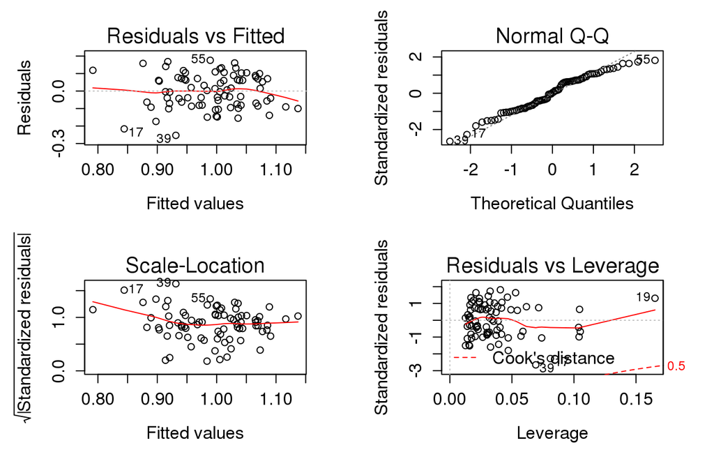

```r
par(mfrow = c(2, 2))
plot(modelis2)
```

## Dispersijas analīze

## Dispersijas analīzes funkcijas

Dispersijas analīzi programmā R veic ar funkciju `aov()`, vai arī kombinējot funkcijas `anova()` un `lm()`.

```r
aov(pētāmā.pazīmē~faktors,data=datu.tabula)

anova(lm(pētāmā.pazīmē~faktors,data=datu.tabula))
```

Lai analīze tiktu veikta pareizi, regresoram (x) ir jābūt izteiktam kā faktoram.

## Dati 1

```r
miezi <- read.table(file = "../Dati/miezi.txt", header = TRUE,sep="\t",dec=".")
```

```r
str(miezi)
```

```
'data.frame':   30 obs. of  2 variables:
 $ skirne: int  1 1 1 1 1 1 1 1 1 1 ...
 $ raza  : num  66.6 70 63.7 72.1 74.2 67.3 73.4 76.2 76.3 66.4 ...
```

```r
head(miezi)
```

```
  skirne raza
1      1 66.6
2      1 70.0
3      1 63.7
4      1 72.1
5      1 74.2
6      1 67.3
```

## Dati 2

```r
summary(miezi)
```

```
     skirne       raza
 Min.   :1   Min.   :63.00
 1st Qu.:1   1st Qu.:69.47
 Median :2   Median :74.60
 Mean   :2   Mean   :74.04
 3rd Qu.:3   3rd Qu.:77.45
 Max.   :3   Max.   :85.40
```

## Vizuālais salīdzinājums

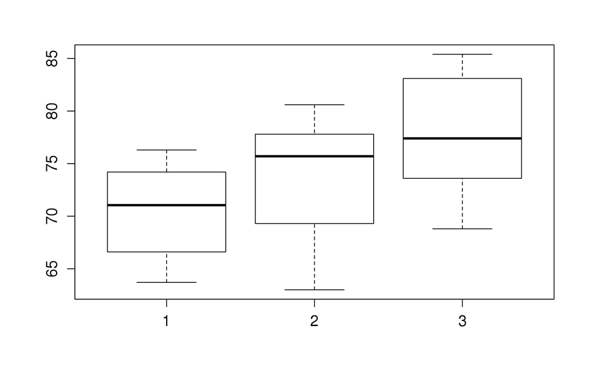

```r
boxplot(miezi$raza~miezi$skirne)
```

## Pārveidošana par faktoru

Lai pārbaudītu vai mainīgais tiek uztverts kā faktors, izmanto funkciju `is.factor()`. Lai mainīgo pārvērstu par faktoru, izmanto funkciju `as.factor()`.

```r
is.factor(miezi$skirne)
```

```
[1] FALSE
```

```r
miezi$skirne<-as.factor(miezi$skirne)
is.factor(miezi$skirne)
```

```
[1] TRUE
```

## Dispersiju salīdzināšana

Pirms dispersijas analīzes veikšanas grupu dispersijas salīdzina ar funkciju `leveneTest()`, kas atrodas paketē `car`.

```r
if (!require("car") )  install.packages("car")
library(car)
leveneTest(y = miezi$raza, group = miezi$skirne)
```

```
Levene's Test for Homogeneity of Variance (center = median)
      Df F value Pr(>F)
group  2  0.1785 0.8375
      27
```

**Secinājums:** pie būtiskuma līmenā \(\alpha=0,05\) starp atsevišķu gradācijas klašu dispersijām nepastāv statistiski būtiska atšķirība jeb dispersijas ir homogēnas, jo iegūtā p vērtība (0,84) ir lielāka par būtiskuma līmeni.

## Vienfaktora dispersijas analīze

```r
anov.miezi <- aov(raza~skirne,data=miezi)
summary(anov.miezi)
```

```
            Df Sum Sq Mean Sq F value Pr(>F)
skirne       2  274.9  137.45   4.596 0.0192 *
Residuals   27  807.6   29.91
---
Signif. codes:  0 '***' 0.001 '**' 0.01 '*' 0.05 '.' 0.1 ' ' 1
```

**Secinājums:** pie būtiskuma līmenā \(\alpha=0,05\) starp gradācijas klašu vidējiem aritmētiskajiem pastāv statistiski būtiska atšķirība jeb faktora šķirne ietekme uz ražu ir būtiska, jo iegūtā p vērtība (0,019) ir mazāka par būtiskuma līmeni.

## Gradācijas klašu salīdzināšana

```r
TukeyHSD(anov.miezi)
```

```
  Tukey multiple comparisons of means
    95% family-wise confidence level

Fit: aov(formula = raza ~ skirne, data = miezi)

$skirne
    diff       lwr       upr     p adj
2-1 2.90 -3.164184  8.964184 0.4716580
3-1 7.36  1.295816 13.424184 0.0150186
3-2 4.46 -1.604184 10.524184 0.1810875
```

**Secinājums:** pie būtiskuma līmenā \(\alpha=0,05\) statistiski būtiska atšķirība pastāv starp 3. un 1. šķirnes ražu (p vērtība 0,015), bet starp 1. un 2., kā arī 2. un 3. šķirni atšķirība nav statistiski būtiska (p vērtības lielākas par 0,05).

## Vidējo vērtību grafiskais attēlojums

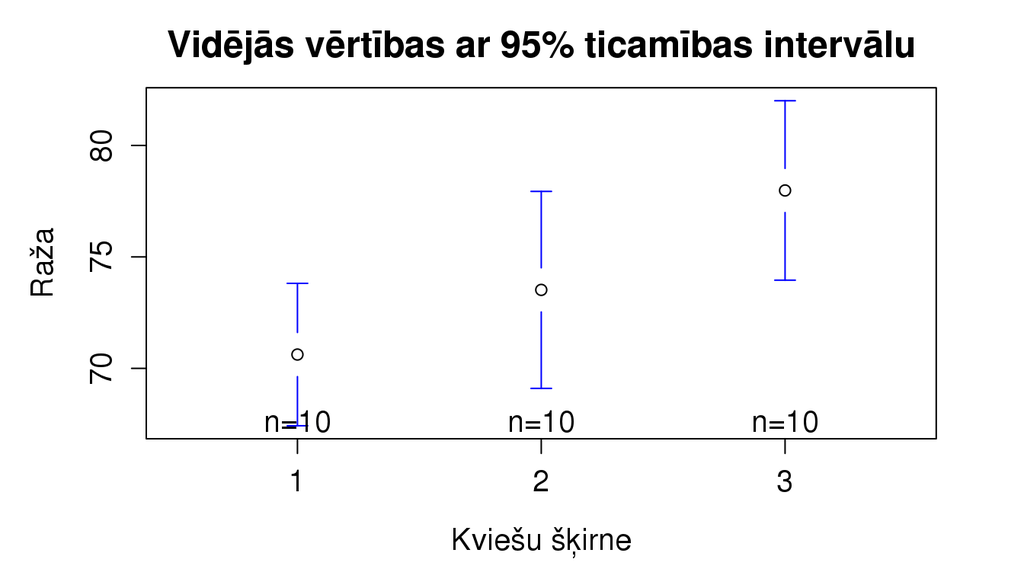

```r
if (!require("gplots") )  install.packages("gplots")
library(gplots)
plotmeans(miezi$raza ~ miezi$skirne,
 connect=FALSE,xlab = "Kviešu šķirne",ylab = "Raža",
 main = "Vidējās vērtības ar 95% ticamības intervālu")
```

## Dati

```r
soja <- read.table(file="../Dati/soja.txt",header=TRUE)
```

```r
str(soja)
```

```
'data.frame':   52 obs. of  3 variables:
 $ gaisma: Factor w/ 2 levels "normala","zema": 2 2 2 2 2 2 2 2 2 2 ...
 $ stress: Factor w/ 2 levels "ir","nav": 2 2 2 2 2 2 2 2 2 2 ...
 $ lapas : int  264 200 225 268 215 241 232 256 229 288 ...
```

```r
head(soja)
```

```
  gaisma stress lapas
1   zema    nav   264
2   zema    nav   200
3   zema    nav   225
4   zema    nav   268
5   zema    nav   215
6   zema    nav   241
```

## Datu pārbaude

```r
names(soja)
```

```
[1] "gaisma" "stress" "lapas"
```

```r
is.factor(soja$gaisma)
```

```
[1] TRUE
```

```r
is.factor(soja$stress)
```

```
[1] TRUE
```

## Dispersiju salīdzināšana

```r
library(car)
leveneTest(y=soja$lapas,group=soja$gaisma:soja$stress)
```

```
Levene's Test for Homogeneity of Variance (center = median)
      Df F value Pr(>F)
group  3  0.1963 0.8984
      48
```

**Secinājums:** pie būtiskuma līmenā \(\alpha=0,05\) starp atsevišķu gradācijas klašu dispersijām nepastāv statistiski būtiska atšķirība jeb dispersijas ir homogēnas, jo iegūtā p vērtība (0,9) ir lielāka par būtiskuma līmeni.

## Daudzfaktoru dispersijas analīze 1

Pieraksts faktors1*faktors2 nozīmē, ka pārbauda katra faktora ietekmi, kā arī faktoru kombinācijas ietekmi.

```r
modelis <- aov(lapas~gaisma*stress,data=soja)
summary(modelis)
```

```
              Df Sum Sq Mean Sq F value   Pr(>F)
gaisma         1  42752   42752  47.749 1.01e-08 ***
stress         1  14858   14858  16.595 0.000173 ***
gaisma:stress  1     26      26   0.029 0.864570
Residuals     48  42976     895
---
Signif. codes:  0 '***' 0.001 '**' 0.01 '*' 0.05 '.' 0.1 ' ' 1
```

## Daudzfaktoru dispersijas analīze 2

**Secinājums:** pie būtiskuma līmenā \(\alpha=0,05\) sojas lapu laukumu būtiski ietekmē gaismas daudzums (p vērtība <0,0001) un stresa līmenis (p vērtība 0,0002), bet faktoru kombinācijas ietekme nav būtiska (p vērtība 0,86).

## Gradācijas klašu salīdzināšana

Šajā gadījumā Post-Hoc testu var arī neveikt, jo faktoram ir tikai divas gradācijas klases - ja faktora ietekme ir būtiska, tad, attiecīgi, šīs klases būtiski atšķiras.

```r
TukeyHSD(modelis,"gaisma")
```

```
  Tukey multiple comparisons of means
    95% family-wise confidence level

Fit: aov(formula = lapas ~ gaisma * stress, data = soja)

$gaisma
                  diff       lwr       upr p adj
zema-normala -57.34615 -74.03228 -40.66003     0
```